# Red Wine Quality Analysis by Karun Gahlawat

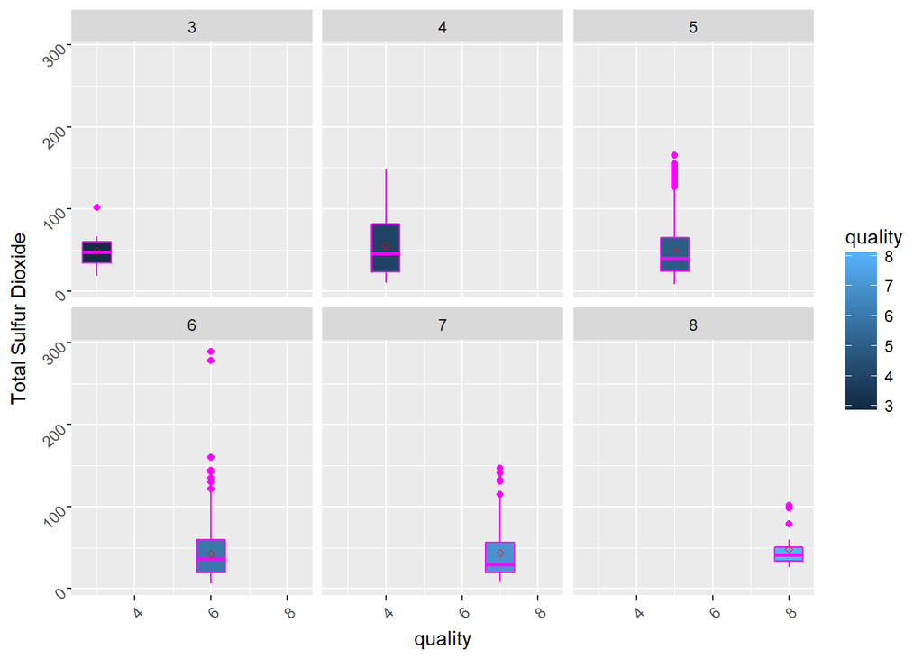

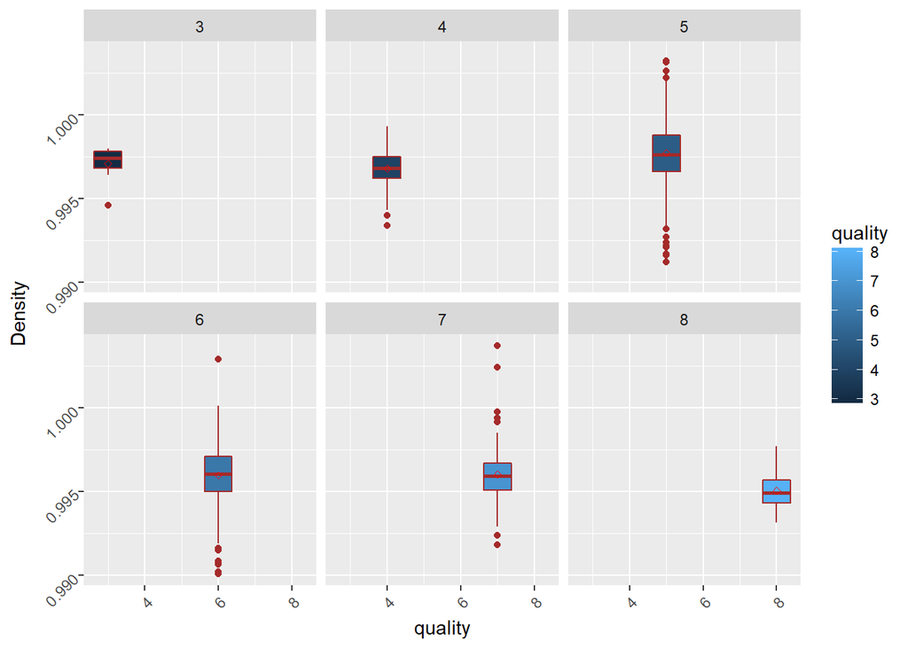

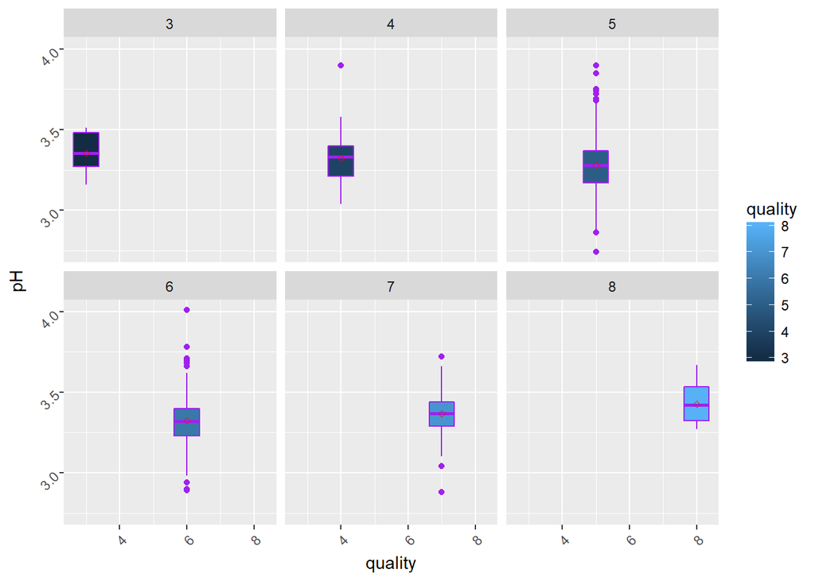

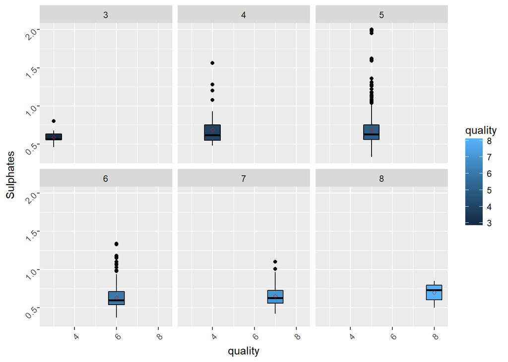

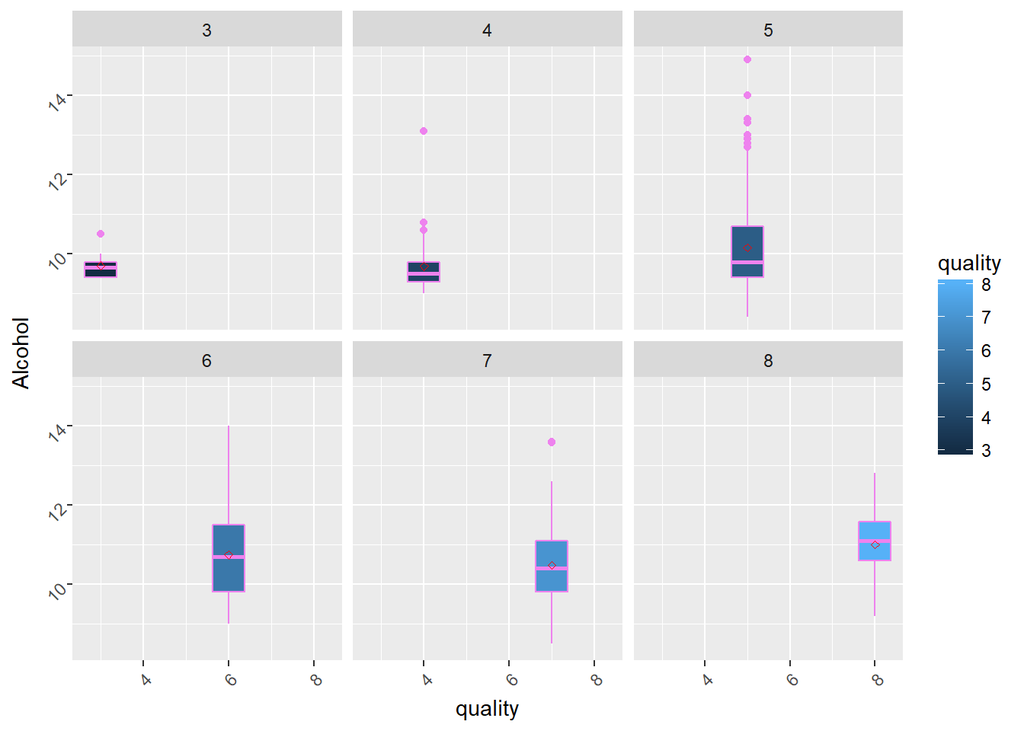

# Bivariate Analysis

### Talk about some of the relationships you observed in this part of the investigation. How did the feature(s) of interest vary with other features in the dataset?

> Some interesting relationships I found in this dataset. When compared means of each feature  
> with means of each feature with quality more than or equal to 8, I found that alcohol, total sulphur dioxide and free sulphur dioxde means are apart from quality means while all other are very close to quality means. It brings up  
> a question whether these feature contribute more or less to the over all quality of wine.

> The boxplots above show a little more information beyond means. A new feature residual sugar has more dispersion  
> around mean.

### Did you observe any interesting relationships between the other features (not the main feature(s) of interest)?

> The other features are distributed closely to the high quality features. Here is what I found Fixed Acidity is positively correlated with Density Fixed Acidity is negatively correlated with PH. (expected!) Volatile Acidity is positively correlated with PH (intereting!) Volatile Acidity is negatively correlated with Citric Acid. It means something other than citric acid contributes to volatile acidity maybe? Citric Acid and Fixed Acidity tend to behave similar. Residual Sugar seem completely independent of all other features Chlorides seem to go along well with Suplphates but seem to be independent of everything else. Free Sulphur Dioxide seem slightly correlated with Total Sulphur Diaoxide but is independent of everything else. Total Sulphur Dioxide is similar to Free Sulphur Dioxide. No relation seem exist with other factors. Density seem to affect a few features. Correlates well with Fixed Acidity, Suplhates, Residual Sugar and Citric Acid. Seem to negatively correlate with Alcohol. This is interesting! PH is mostly expected behavior. Negative to No correlation with Fixed Acidity and very tiny relation with Alcohol and Volatile Acidity. Suplhates is interesting. It is going with no to slightly positively correlated with all other features. Alcohol is not going along with any other feature except Density. It seem to negatively correlate with Density.

### What was the strongest relationship you found?

> Strongest relationship is Density. It is playing a role with several other factors although not effecting Quality directly. Wines with high quality has density really close to mean.

# Multivariate Plots Section

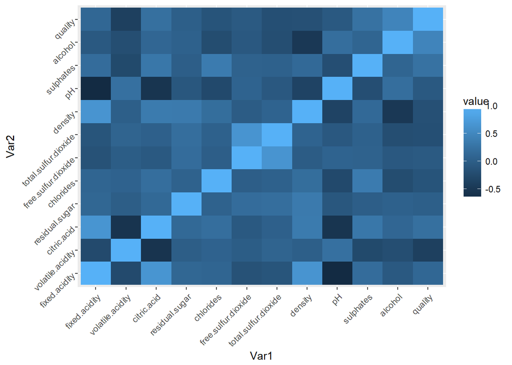

```
##
## Call:
## lm(formula = quality ~ pH + density + citric.acid + alcohol +
##     total.sulfur.dioxide, data = rwdata_corr)
##
## Coefficients:
##          (Intercept)                    pH               density
##            17.147969             -0.455169            -13.579180
##          citric.acid               alcohol  total.sulfur.dioxide
##             0.605212              0.334242             -0.002531
```

```
##
## Call:
## lm(formula = quality ~ pH + density + citric.acid + alcohol +
##     total.sulfur.dioxide, data = rwdata_corr)
##
## Residuals:
##      Min       1Q   Median       3Q      Max
## -2.66730 -0.38468 -0.09699  0.49623  2.33786
##
## Coefficients:
##                        Estimate Std. Error t value Pr(>|t|)
## (Intercept)           1.715e+01  1.216e+01   1.410   0.1588
## pH                   -4.552e-01  1.402e-01  -3.245   0.0012 **
## density              -1.358e+01  1.208e+01  -1.124   0.2613
## citric.acid           6.052e-01  1.205e-01   5.021 5.72e-07 ***
## alcohol               3.342e-01  2.119e-02  15.770  < 2e-16 ***
## total.sulfur.dioxide -2.531e-03  5.385e-04  -4.700 2.82e-06 ***
## ---
## Signif. codes:  0 '***' 0.001 '**' 0.01 '*' 0.05 '.' 0.1 ' ' 1
##
## Residual standard error: 0.6898 on 1593 degrees of freedom
## Multiple R-squared:  0.2727, Adjusted R-squared:  0.2704
## F-statistic: 119.5 on 5 and 1593 DF,  p-value: < 2.2e-16
```

[figure not shown]

[figure not shown]

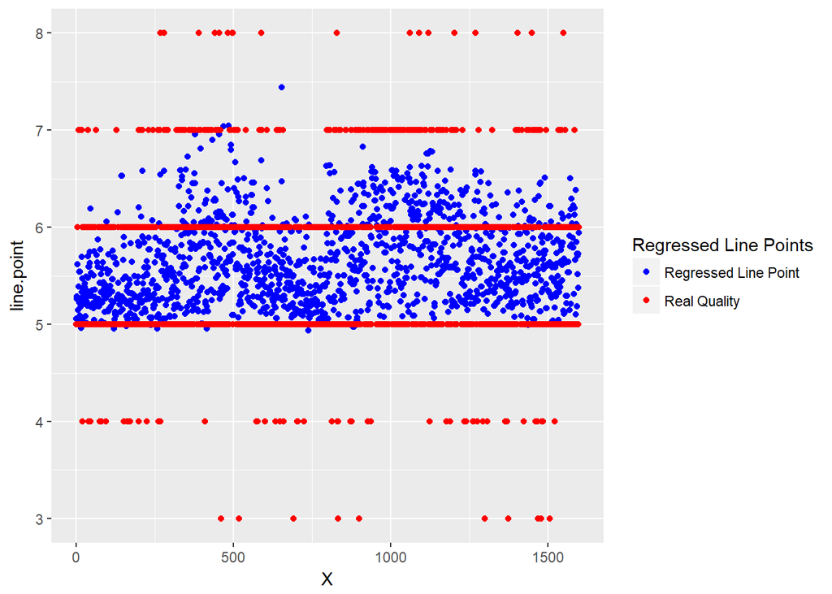

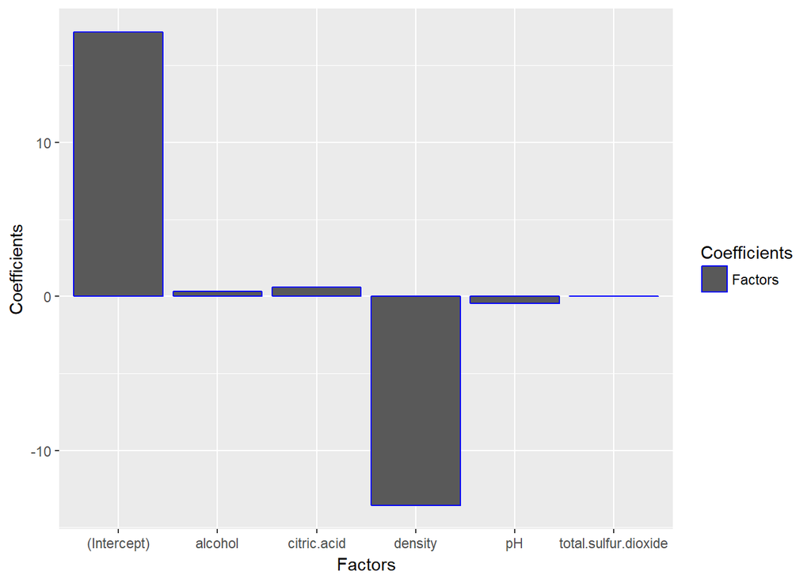

```
##
## Call:
## lm(formula = quality ~ density + fixed.acidity + sulphates +
##     residual.sugar, data = rwdata_corr)
##
## Coefficients:
##    (Intercept)         density   fixed.acidity       sulphates
##      241.24170      -239.08362         0.20050         1.21191
## residual.sugar
##        0.09235
```

```
##
## Call:
## lm(formula = quality ~ density + fixed.acidity + sulphates +
##     residual.sugar, data = rwdata_corr)
##
## Residuals:
##      Min       1Q   Median       3Q      Max
## -2.83608 -0.44457 -0.07961  0.53003  2.23778
##
## Coefficients:
##                  Estimate Std. Error t value Pr(>|t|)
## (Intercept)     241.24170   13.62974  17.700  < 2e-16 ***
## density        -239.08362   13.76876 -17.364  < 2e-16 ***
## fixed.acidity     0.20050    0.01411  14.209  < 2e-16 ***
## sulphates         1.21191    0.10749  11.274  < 2e-16 ***
## residual.sugar    0.09235    0.01380   6.692 3.03e-11 ***
## ---
## Signif. codes:  0 '***' 0.001 '**' 0.01 '*' 0.05 '.' 0.1 ' ' 1
##
## Residual standard error: 0.7153 on 1594 degrees of freedom
## Multiple R-squared:  0.2175, Adjusted R-squared:  0.2156
## F-statistic: 110.8 on 4 and 1594 DF,  p-value: < 2.2e-16
```

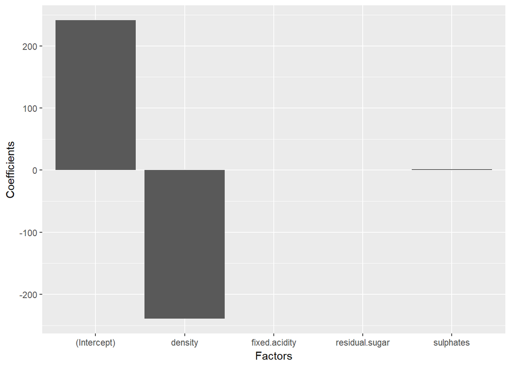

```
##
## Call:
## lm(formula = quality ~ density + volatile.acidity + free.sulfur.dioxide +
##     chlorides, data = rwdata_corr)
##
## Coefficients:
##         (Intercept)              density     volatile.acidity
##           71.902882           -65.384954            -1.728409
## free.sulfur.dioxide            chlorides
##           -0.004449            -1.277216
```

```
##
## Call:
## lm(formula = quality ~ density + volatile.acidity + free.sulfur.dioxide +
##     chlorides, data = rwdata_corr)
##
## Residuals:
##     Min      1Q  Median      3Q     Max
## -2.5308 -0.5360 -0.0244  0.4807  2.6118
##
## Coefficients:
##                       Estimate Std. Error t value Pr(>|t|)
## (Intercept)          71.902882   9.816964   7.324 3.79e-13 ***
## density             -65.384954   9.855569  -6.634 4.45e-11 ***
## volatile.acidity     -1.728409   0.101937 -16.956  < 2e-16 ***
## free.sulfur.dioxide  -0.004449   0.001742  -2.554  0.01076 *
## chlorides            -1.277216   0.395774  -3.227  0.00128 **
## ---
## Signif. codes:  0 '***' 0.001 '**' 0.01 '*' 0.05 '.' 0.1 ' ' 1
##
## Residual standard error: 0.7282 on 1594 degrees of freedom
## Multiple R-squared:  0.1889, Adjusted R-squared:  0.1869
## F-statistic: 92.82 on 4 and 1594 DF,  p-value: < 2.2e-16
```

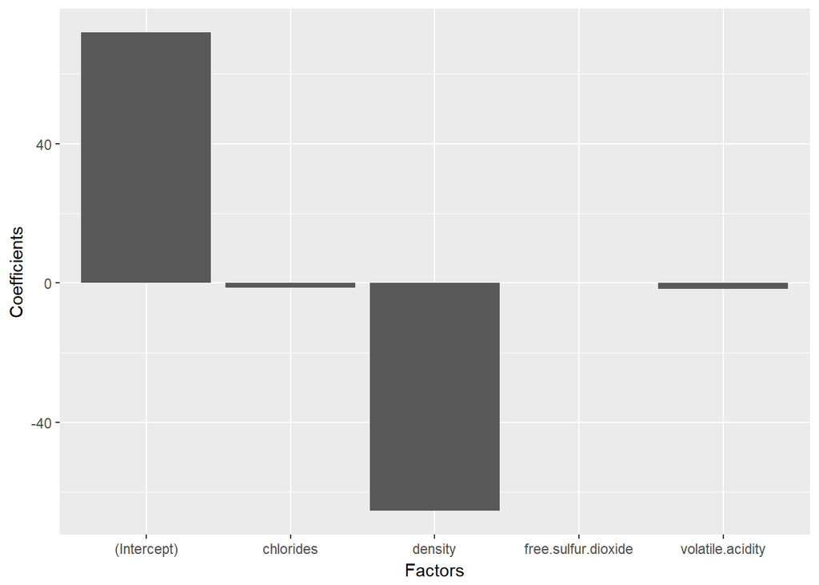

```
##
## Call:
## lm(formula = quality ~ density + alcohol, data = rwdata_corr)
##
## Coefficients:
## (Intercept)      density      alcohol
##    -33.1524      34.8217       0.3914
```

```
##
## Call:
## lm(formula = quality ~ density + alcohol, data = rwdata_corr)
##
## Residuals:
##     Min      1Q  Median      3Q     Max
## -2.9376 -0.3914 -0.1429  0.5263  2.5556
##
## Coefficients:
##              Estimate Std. Error t value Pr(>|t|)
## (Intercept) -33.15238   10.87817  -3.048  0.00234 **
## density      34.82170   10.81292   3.220  0.00131 **
## alcohol       0.39144    0.01915  20.441  < 2e-16 ***
## ---
## Signif. codes:  0 '***' 0.001 '**' 0.01 '*' 0.05 '.' 0.1 ' ' 1
##
## Residual standard error: 0.7083 on 1596 degrees of freedom
## Multiple R-squared:  0.2317, Adjusted R-squared:  0.2308
## F-statistic: 240.7 on 2 and 1596 DF,  p-value: < 2.2e-16
```

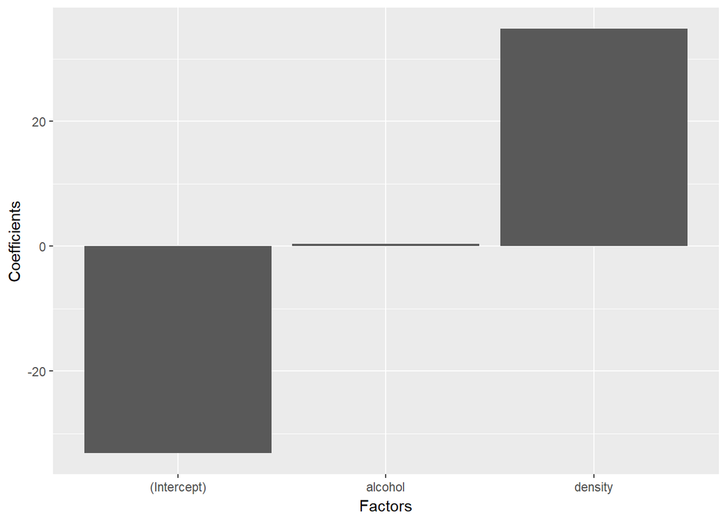

# Multivariate Analysis

### Talk about some of the relationships you observed in this part of the investigation. Were there features that strengthened each other in terms of looking at your feature(s) of interest?

> I noticed a few relationships interesting to quote here. Total Sulphur Dioxide and Free Sulphur Dioxide overlap each other and we only need one of these. Four other features interest me. Citric acid, density, ph and alcohol. Citric acid controls fixed acidity and affects ph and alcohol and sulphates. Density effects various other features as well PH does not seem to effect other features positively but seem to negatively effect other features. Alcohol is interesting as it seem to go along with other features but negatively effect density. From all these interactions it is hard to gather a combined effect of these features but they do present interesting behavior.

### Were there any interesting or surprising interactions between features?

> Yes, most surprising interaction is that none of the features directly effect quality that much. Along with this, these features do NOT interact with each other too much with a few expected negative correlations. This behavior indicates quality of wines cannot be simply explained by individual features even if these features show some interaction with each other.

# Final Plots and Summary

### Plot One

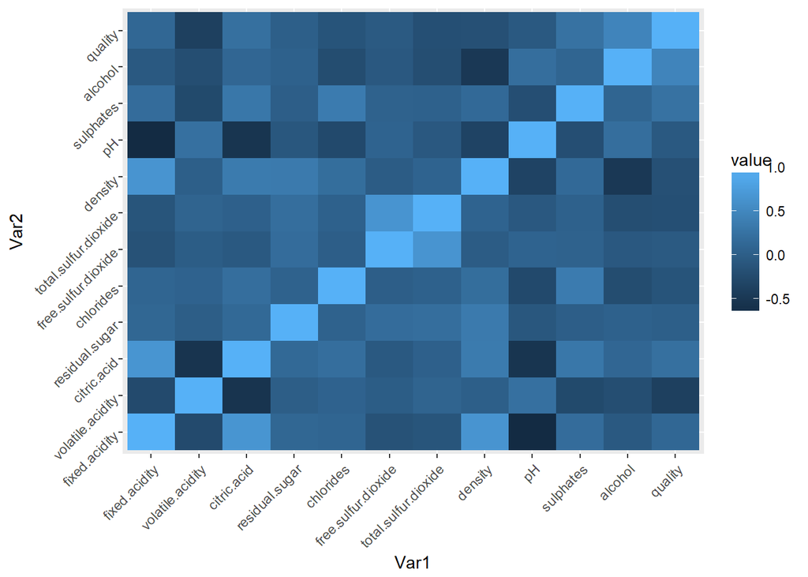

### Plot Two

[figure not shown]

### Plot Three

```
##
## Call:
## lm(formula = quality ~ density + alcohol, data = rwdata_corr)
##
## Coefficients:
## (Intercept)      density      alcohol
##    -33.1524      34.8217       0.3914
```

```
##
## Call:
## lm(formula = quality ~ density + alcohol, data = rwdata_corr)
##
## Residuals:
##     Min      1Q  Median      3Q     Max
## -2.9376 -0.3914 -0.1429  0.5263  2.5556
##
## Coefficients:
##              Estimate Std. Error t value Pr(>|t|)
## (Intercept) -33.15238   10.87817  -3.048  0.00234 **
## density      34.82170   10.81292   3.220  0.00131 **
## alcohol       0.39144    0.01915  20.441  < 2e-16 ***
## ---
## Signif. codes:  0 '***' 0.001 '**' 0.01 '*' 0.05 '.' 0.1 ' ' 1
##
## Residual standard error: 0.7083 on 1596 degrees of freedom
## Multiple R-squared:  0.2317, Adjusted R-squared:  0.2308
## F-statistic: 240.7 on 2 and 1596 DF,  p-value: < 2.2e-16
```

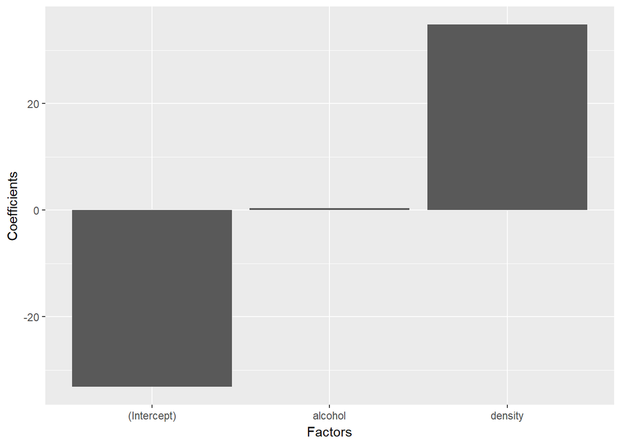

### Description Three

> I chose this plot to complete our exploration of above plot. This plot is a linear model showing effects of density and alcohol combined to quality of wine. The chart above is a plot of how coefficients of density and alcohol measure along with interception coefficient. The Console shows similar things in numbers and model output. As we show these coefficients, we understand that the coefficient of density is substantially larger than alcohol. This means that a small change in density substantially changes the quality of wine. As compared to density, alcohol coefficient is very small. Smalle coefficient means alcohol needs to change a lot for quality to change. Along with density and alcohol, we also notice that model is heavily biased with the intercept coefficient substantially large and negative. It tells us whatever density changes does to quality of wine, bias in model undoes it more or less. Overall, there is no good linear model to explain how these factors effect quality of wine! ——

# Reflection

> Data set explored here is already tidy so not much cleanup or mining to do here. That made exploration job little easier. The plan of action then is to explore each factor on its own, then see how they behave with each other and then notice how they behave with quality of wine.

> For individual factors I plotted scatter and histogram along with basic descriptive statistics like mean etc… Scatter plot gives an initial intuition around distribution of a factor in the dataset. Histogram tunes it a little bit showing how close or far is the distribution to normal. Initially I tried to code each factor but then decided to plot in a loop. Looks more efficient that way.

> Another step was to see how means of factors of wines with quality 8 or more compared with overall means of factors. Which factors mean were close the good wines means?

> Another step to continue explore how factors behave was to plot box plots filled by quality. I wanted to see how the distrbution looks like for each quality rating. Mins, Maxs, overall spreads, how far apart are some points from mean and the lower and higher quartile. Fitting box plots took some time and ggplot fiddling. Finally I got to a point where plots looks decent with some story to tell. It was interesting to find distribution of higher quality wines of most of our factors are pretty close to mean.

> Exploration would be incomplete without correlation plot of all factors with each other. This also took some learning and struggle. Along with learning it surprised me that none of the factors were highly correlated with quality. This is also the first time I found that density plays some important role.

> It is clear that linear relationship does not play here. So next steps would be to apply non linear models like logistic regression. With more data, some deep learning methedology could also be utilized to learn how factors contribute to quality. SVMs can be used to cluster some factors and see if we can reduce some dimensionality and try other models like random forest.